# Hydroelectric Energy and Greenhouse Gas Emissions

Ethan McChristian

08 June 2020

### This model uses data from the World Data Bank from 2005-2020 to test the relationship between countries that produce more hydroelectric energy (percentage of total energy production) and their percapita greenhouse gas emissions, in kilotonnes of carbon dioxide equivalent. As you will see later on, the data from 2008-2020 is not complete and therefore is excluded from the model. This is my first independent regression and therefore, I welcome any and all criticisms. If you see this model and are abhorred by methods, please reach out and tell me what I could’ve done better.

# Data Wrangling

### Importing the data, summarizing

```r
hydro_data <- readr::read_csv("/Users/EthanMcChristian/Desktop/hydro_co2.csv")
```

### Cleaning column names

```r
hydro_data <- clean_names(hydro_data)
hydro_data
```

```
## # A tibble: 3,965 x 23
##     time time_code country_name country_code co2_emissions_m… access_to_elect…
##    <dbl> <chr>     <chr>        <chr>        <chr>            <chr>
##  1  2005 YR2005    Afghanistan  AFG          0.0517439645638… 23
##  2  2005 YR2005    Albania      ALB          1.41249821101668 ..
##  3  2005 YR2005    Algeria      DZA          3.23616827096358 ..
##  4  2005 YR2005    American Sa… ASM          ..               ..
##  5  2005 YR2005    Andorra      AND          7.29987193629782 100
##  6  2005 YR2005    Angola       AGO          0.9857363549999… 28.2321949005127
##  7  2005 YR2005    Antigua and… ATG          5.26654391456454 92.2
##  8  2005 YR2005    Argentina    ARG          4.16812854757591 96.8673934936523
##  9  2005 YR2005    Armenia      ARM          1.46002557971119 99.8
## 10  2005 YR2005    Aruba        ABW          27.200707780588  100
## # … with 3,955 more rows, and 17 more variables:
## #   gni_per_capita_atlas_method_current_us_ny_gnp_pcap_cd <chr>,
## #   co2_emissions_kt_en_atm_co2e_kt <chr>,
## #   co2_emissions_from_gaseous_fuel_consumption_percent_of_total_en_atm_co2e_gf_zs <chr>,
## #   co2_emissions_from_solid_fuel_consumption_percent_of_total_en_atm_co2e_sf_zs <chr>,
## #   co2_emissions_from_liquid_fuel_consumption_percent_of_total_en_atm_co2e_lf_zs <chr>,
## #   methane_emissions_in_energy_sector_thousand_metric_tons_of_co2_equivalent_en_atm_meth_eg_kt_ce <chr>,
## #   agricultural_methane_emissions_thousand_metric_tons_of_co2_equivalent_en_atm_meth_ag_kt_ce <chr>,
## #   total_greenhouse_gas_emissions_kt_of_co2_equivalent_en_atm_ghgt_kt_ce <chr>,
## #   people_using_safely_managed_drinking_water_services_percent_of_population_sh_h2o_smdw_zs <chr>,
## #   electricity_production_from_hydroelectric_sources_percent_of_total_eg_elc_hyro_zs <chr>,
## #   electricity_production_from_coal_sources_percent_of_total_eg_elc_coal_zs <chr>,
## #   electricity_production_from_natural_gas_sources_percent_of_total_eg_elc_ngas_zs <chr>,
## #   electricity_production_from_nuclear_sources_percent_of_total_eg_elc_nucl_zs <chr>,
## #   electricity_production_from_oil_gas_and_coal_sources_percent_of_total_eg_elc_fosl_zs <chr>,
## #   electricity_production_from_renewable_sources_excluding_hydroelectric_percent_of_total_eg_elc_rnwx_zs <chr>,
## #   electric_power_consumption_k_wh_per_capita_eg_use_elec_kh_pc <chr>,
## #   population_total_sp_pop_totl <chr>
```

```r
hydro_data <-
  hydro_data %>%
  rename(
 co2_percap = co2_emissions_metric_tons_per_capita_en_atm_co2e_pc,
 perc_elec = access_to_electricity_percent_of_population_eg_elc_accs_zs,
 gni_percap = gni_per_capita_atlas_method_current_us_ny_gnp_pcap_cd,
 co2_emission = co2_emissions_kt_en_atm_co2e_kt,
 perc_co2_gaseous = co2_emissions_from_gaseous_fuel_consumption_percent_of_total_en_atm_co2e_gf_zs,
 perc_co2_solid_fuel = co2_emissions_from_solid_fuel_consumption_percent_of_total_en_atm_co2e_sf_zs,
 perc_co2_liquid_fuel = co2_emissions_from_liquid_fuel_consumption_percent_of_total_en_atm_co2e_lf_zs,
 co2_methane_equiv.energy_sector = methane_emissions_in_energy_sector_thousand_metric_tons_of_co2_equivalent_en_atm_meth_eg_kt_ce,
 co2_methane_equiv.agriculture = agricultural_methane_emissions_thousand_metric_tons_of_co2_equivalent_en_atm_meth_ag_kt_ce,
 co2_total_greenhouse_equiv = total_greenhouse_gas_emissions_kt_of_co2_equivalent_en_atm_ghgt_kt_ce,
 perc_safe_water = people_using_safely_managed_drinking_water_services_percent_of_population_sh_h2o_smdw_zs,
 hydro_electric_perc = electricity_production_from_hydroelectric_sources_percent_of_total_eg_elc_hyro_zs,
 coal_electric_perc = electricity_production_from_coal_sources_percent_of_total_eg_elc_coal_zs,
 natural_gas_electric_perc = electricity_production_from_natural_gas_sources_percent_of_total_eg_elc_ngas_zs,
 nuclear_electric_perc = electricity_production_from_nuclear_sources_percent_of_total_eg_elc_nucl_zs,
 oil_gas_coal_electric_perc = electricity_production_from_oil_gas_and_coal_sources_percent_of_total_eg_elc_fosl_zs,
 renewable_electric_nohydro_perc = electricity_production_from_renewable_sources_excluding_hydroelectric_percent_of_total_eg_elc_rnwx_zs,
 electric_consumption_percap = electric_power_consumption_k_wh_per_capita_eg_use_elec_kh_pc,
 pop = population_total_sp_pop_totl
  )
hydro_data
```

```
## # A tibble: 3,965 x 23
##     time time_code country_name country_code co2_percap perc_elec gni_percap
##    <dbl> <chr>     <chr>        <chr>        <chr>      <chr>     <chr>
##  1  2005 YR2005    Afghanistan  AFG          0.0517439… 23        ..
##  2  2005 YR2005    Albania      ALB          1.4124982… ..        2620
##  3  2005 YR2005    Algeria      DZA          3.2361682… ..        2710
##  4  2005 YR2005    American Sa… ASM          ..         ..        ..
##  5  2005 YR2005    Andorra      AND          7.2998719… 100       ..
##  6  2005 YR2005    Angola       AGO          0.9857363… 28.23219… 1370
##  7  2005 YR2005    Antigua and… ATG          5.2665439… 92.2      12410
##  8  2005 YR2005    Argentina    ARG          4.1681285… 96.86739… 4260
##  9  2005 YR2005    Armenia      ARM          1.4600255… 99.8      1540
## 10  2005 YR2005    Aruba        ABW          27.200707… 100       19200
## # … with 3,955 more rows, and 16 more variables: co2_emission <chr>,
## #   perc_co2_gaseous <chr>, perc_co2_solid_fuel <chr>,
## #   perc_co2_liquid_fuel <chr>, co2_methane_equiv.energy_sector <chr>,
## #   co2_methane_equiv.agriculture <chr>, co2_total_greenhouse_equiv <chr>,
## #   perc_safe_water <chr>, hydro_electric_perc <chr>, coal_electric_perc <chr>,
## #   natural_gas_electric_perc <chr>, nuclear_electric_perc <chr>,
## #   oil_gas_coal_electric_perc <chr>, renewable_electric_nohydro_perc <chr>,
## #   electric_consumption_percap <chr>, pop <chr>
```

### Replacing all “..” with NA’s

```r
hydro_data <- hydro_data %>%
  mutate(co2_percap = na_if(co2_percap, "..")) %>%
  mutate(perc_elec = na_if(perc_elec, "..")) %>%
  mutate(gni_percap = na_if(gni_percap, "..")) %>%
  mutate(co2_emission = na_if(co2_emission, "..")) %>%
  mutate(perc_co2_gaseous = na_if(perc_co2_gaseous, "..")) %>%
  mutate(perc_co2_solid_fuel = na_if(perc_co2_solid_fuel, "..")) %>%
  mutate(perc_co2_liquid_fuel = na_if(perc_co2_liquid_fuel, "..")) %>%
  mutate(co2_methane_equiv.energy_sector = na_if(co2_methane_equiv.energy_sector, "..")) %>%
  mutate(co2_methane_equiv.agriculture = na_if(co2_methane_equiv.agriculture, "..")) %>%
  mutate(co2_total_greenhouse_equiv = na_if(co2_total_greenhouse_equiv, "..")) %>%
  mutate(perc_safe_water = na_if(perc_safe_water, "..")) %>%
  mutate(hydro_electric_perc = na_if(hydro_electric_perc, "..")) %>%
  mutate(coal_electric_perc = na_if(coal_electric_perc, "..")) %>%
  mutate(natural_gas_electric_perc = na_if(natural_gas_electric_perc, "..")) %>%
  mutate(nuclear_electric_perc = na_if(nuclear_electric_perc, "..")) %>%
  mutate(oil_gas_coal_electric_perc = na_if(oil_gas_coal_electric_perc, "..")) %>%
  mutate(renewable_electric_nohydro_perc = na_if(renewable_electric_nohydro_perc, "..")) %>%
  mutate(electric_consumption_percap = na_if(electric_consumption_percap, "..")) %>%
  mutate(pop = na_if(pop, ".."))
```

### Deleting all rows with NA’s, converting all character variables to numeric

```r
hydro_data_subset <- hydro_data[complete.cases(hydro_data), ]
hydro_data_subset
```

```
## # A tibble: 385 x 23
##     time time_code country_name country_code co2_percap perc_elec gni_percap
##    <dbl> <chr>     <chr>        <chr>        <chr>      <chr>     <chr>
##  1  2005 YR2005    Armenia      ARM          1.4600255… 99.8      1540
##  2  2005 YR2005    Austria      AUT          9.0201695… 100       38720
##  3  2005 YR2005    Azerbaijan   AZE          4.0918019… 99.32710… 1270
##  4  2005 YR2005    Bahrain      BHR          21.602028… 100       16550
##  5  2005 YR2005    Bangladesh   BGD          0.2839484… 44.23     550
##  6  2005 YR2005    Belarus      BLR          6.1224715… 100       2810
##  7  2005 YR2005    Belgium      BEL          10.355392… 100       37730
##  8  2005 YR2005    Bosnia and … BIH          4.3035985… 100       3180
##  9  2005 YR2005    Bulgaria     BGR          6.2562820… 100       3770
## 10  2005 YR2005    Cambodia     KHM          0.2091347… 20.5      460
## # … with 375 more rows, and 16 more variables: co2_emission <chr>,
## #   perc_co2_gaseous <chr>, perc_co2_solid_fuel <chr>,
## #   perc_co2_liquid_fuel <chr>, co2_methane_equiv.energy_sector <chr>,
## #   co2_methane_equiv.agriculture <chr>, co2_total_greenhouse_equiv <chr>,
## #   perc_safe_water <chr>, hydro_electric_perc <chr>, coal_electric_perc <chr>,
## #   natural_gas_electric_perc <chr>, nuclear_electric_perc <chr>,
## #   oil_gas_coal_electric_perc <chr>, renewable_electric_nohydro_perc <chr>,
## #   electric_consumption_percap <chr>, pop <chr>
```

```r
hydro_data_subnum <- hydro_data_subset %>%
  mutate(co2_percap = as.numeric(co2_percap)) %>%
  mutate(perc_elec = as.numeric(perc_elec)) %>%
  mutate(gni_percap = as.numeric(gni_percap)) %>%
  mutate(co2_emission = as.numeric(co2_emission)) %>%
  mutate(perc_co2_gaseous = as.numeric(perc_co2_gaseous)) %>%
  mutate(perc_co2_solid_fuel = as.numeric(perc_co2_solid_fuel)) %>%
  mutate(perc_co2_liquid_fuel = as.numeric(perc_co2_liquid_fuel)) %>%
  mutate(co2_methane_equiv.energy_sector = as.numeric(co2_methane_equiv.energy_sector)) %>%
  mutate(co2_methane_equiv.agriculture = as.numeric(co2_methane_equiv.agriculture)) %>%
  mutate(co2_total_greenhouse_equiv = as.numeric(co2_total_greenhouse_equiv)) %>%
  mutate(perc_safe_water = as.numeric(perc_safe_water)) %>%
  mutate(hydro_electric_perc = as.numeric(hydro_electric_perc)) %>%
  mutate(coal_electric_perc = as.numeric(coal_electric_perc)) %>%
  mutate(natural_gas_electric_perc = as.numeric(natural_gas_electric_perc)) %>%
  mutate(nuclear_electric_perc = as.numeric(nuclear_electric_perc)) %>%
  mutate(oil_gas_coal_electric_perc = as.numeric(oil_gas_coal_electric_perc)) %>%
  mutate(renewable_electric_nohydro_perc = as.numeric(renewable_electric_nohydro_perc)) %>%
  mutate(electric_consumption_percap = as.numeric(electric_consumption_percap)) %>%
  mutate(pop = as.numeric(pop))
```

NOTE: the data set has shrunk from 3965 observations to only 385, which means we deleted a LOT there. With this newer model, we have certaintly introduced selection (or reporting) bias. This means that countries that did not report any number of inputs is not counted in the regression. Are the countries who did not report a value more likely to have illicit greenhouse gas emissions taking place?

### Converting my “time” values to time series data

```r
hydro_data_subnum <- hydro_data_subnum %>%
  mutate(time = as.character(time))
hydro_data_subnum_date <- hydro_data_subnum %>%
  mutate(time = as.Date(time, "%Y"))
```

### Adding a “percapita greenhouse gas emissions in kt of co2 equivalent” column.

```r
hydro_data_new <- hydro_data_subnum_date %>%
  mutate(percap_greenhouse = co2_total_greenhouse_equiv/pop)
hydro_data_new
```

```
## # A tibble: 385 x 24
##    time       time_code country_name country_code co2_percap perc_elec
##    <date>     <chr>     <chr>        <chr>             <dbl>     <dbl>
##  1 2005-06-08 YR2005    Armenia      ARM               1.46       99.8
##  2 2005-06-08 YR2005    Austria      AUT               9.02      100
##  3 2005-06-08 YR2005    Azerbaijan   AZE               4.09       99.3
##  4 2005-06-08 YR2005    Bahrain      BHR              21.6       100
##  5 2005-06-08 YR2005    Bangladesh   BGD               0.284      44.2
##  6 2005-06-08 YR2005    Belarus      BLR               6.12      100
##  7 2005-06-08 YR2005    Belgium      BEL              10.4       100
##  8 2005-06-08 YR2005    Bosnia and … BIH               4.30      100
##  9 2005-06-08 YR2005    Bulgaria     BGR               6.26      100
## 10 2005-06-08 YR2005    Cambodia     KHM               0.209      20.5
## # … with 375 more rows, and 18 more variables: gni_percap <dbl>,
## #   co2_emission <dbl>, perc_co2_gaseous <dbl>, perc_co2_solid_fuel <dbl>,
## #   perc_co2_liquid_fuel <dbl>, co2_methane_equiv.energy_sector <dbl>,
## #   co2_methane_equiv.agriculture <dbl>, co2_total_greenhouse_equiv <dbl>,
## #   perc_safe_water <dbl>, hydro_electric_perc <dbl>, coal_electric_perc <dbl>,
## #   natural_gas_electric_perc <dbl>, nuclear_electric_perc <dbl>,
## #   oil_gas_coal_electric_perc <dbl>, renewable_electric_nohydro_perc <dbl>,
## #   electric_consumption_percap <dbl>, pop <dbl>, percap_greenhouse <dbl>
```

### Filtering data by middle income countries (UN World Economic Situation and Prospects) and by countries with access to drinking water equal to or above the world average.

```r
hydro_data_new2 <-hydro_data_new %>%
  filter(gni_percap >= 996) %>%
  filter(perc_safe_water >= (530/7.9))
hydro_data_choice <- hydro_data_new2 %>%
  filter(country_name != "Central Europe and the Baltics" & country_name != "Euro Area" & country_name != "Europe and Central Asia" & country_name != "Europe and Central Asia (excluding high income)" & country_name != "Europe and Central Asia (IDA and IBRD countries)" & country_name != "European Union" & country_name != "High income" & country_name != "North America" & country_name != "OECD members" & country_name != "Post-demographic dividend")
```

# Tests, coefficients, and relationships

### Running a hedonic model to test the relationship between percent hydroelectric energy production and percapita greenhouse gas emissions in kilotonnes (1000kg) of co2 equivalent. H0: B1 = 0. HA: B1 != 0.

```r
reg2 <- lm(percap_greenhouse ~ hydro_electric_perc + coal_electric_perc + nuclear_electric_perc + natural_gas_electric_perc + oil_gas_coal_electric_perc + renewable_electric_nohydro_perc + log(electric_consumption_percap) + log(pop) + perc_elec, data = hydro_data_choice)
summary(reg2)
```

```
##
## Call:
## lm(formula = percap_greenhouse ~ hydro_electric_perc + coal_electric_perc +
##     nuclear_electric_perc + natural_gas_electric_perc + oil_gas_coal_electric_perc +
##     renewable_electric_nohydro_perc + log(electric_consumption_percap) +
##     log(pop) + perc_elec, data = hydro_data_choice)
##
## Residuals:
##       Min        1Q    Median        3Q       Max
## -0.013165 -0.003418 -0.000344  0.002355  0.038001
##
## Coefficients:
##                                    Estimate Std. Error t value Pr(>|t|)
## (Intercept)                       2.263e-01  7.828e-02   2.890 0.004223 **
## hydro_electric_perc              -6.502e-05  3.792e-05  -1.715 0.087796 .
## coal_electric_perc                3.359e-05  2.770e-05   1.213 0.226484
## nuclear_electric_perc            -7.968e-05  4.126e-05  -1.931 0.054729 .
## natural_gas_electric_perc         1.199e-04  2.511e-05   4.776 3.21e-06 ***
## oil_gas_coal_electric_perc       -4.120e-05  3.992e-05  -1.032 0.303126
## renewable_electric_nohydro_perc  -3.670e-04  8.677e-05  -4.230 3.40e-05 ***
## log(electric_consumption_percap)  9.806e-03  7.483e-04  13.105  < 2e-16 ***
## log(pop)                         -4.288e-04  2.744e-04  -1.562 0.119573
## perc_elec                        -2.899e-03  8.120e-04  -3.570 0.000435 ***
## ---
## Signif. codes:  0 '***' 0.001 '**' 0.01 '*' 0.05 '.' 0.1 ' ' 1
##
## Residual standard error: 0.006336 on 227 degrees of freedom
## Multiple R-squared:  0.5628, Adjusted R-squared:  0.5455
## F-statistic: 32.47 on 9 and 227 DF,  p-value: < 2.2e-16
```

### Regressing percap_greenhouse without other independent variables

```r
reg1 <- lm(percap_greenhouse ~ hydro_electric_perc, data = hydro_data_choice)
summary(reg1)
```

```
##
## Call:
## lm(formula = percap_greenhouse ~ hydro_electric_perc, data = hydro_data_choice)
##
## Residuals:
##       Min        1Q    Median        3Q       Max
## -0.011039 -0.004398 -0.002929  0.001789  0.056610
##
## Coefficients:
##                       Estimate Std. Error t value Pr(>|t|)
## (Intercept)          1.433e-02  7.567e-04  18.933  < 2e-16 ***
## hydro_electric_perc -8.105e-05  2.267e-05  -3.574 0.000426 ***
## ---
## Signif. codes:  0 '***' 0.001 '**' 0.01 '*' 0.05 '.' 0.1 ' ' 1
##
## Residual standard error: 0.009173 on 235 degrees of freedom
## Multiple R-squared:  0.05156,    Adjusted R-squared:  0.04753
## F-statistic: 12.78 on 1 and 235 DF,  p-value: 0.000426
```

### For visual ques, we’re mapping the relationship between percent of total energy production accounted for by hydroelectric energy.

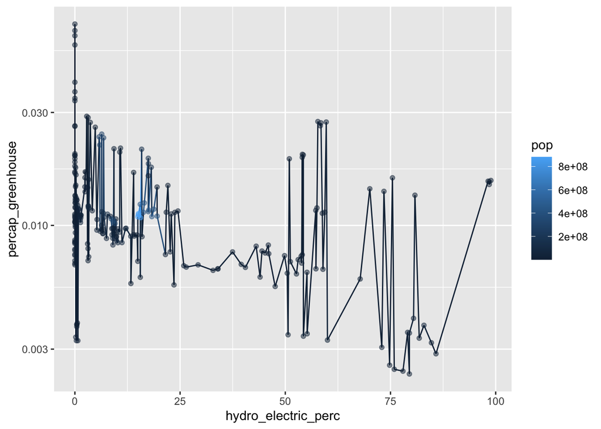

```r
ggplot(data = hydro_data_choice, aes(x = hydro_electric_perc, y = percap_greenhouse, color = pop)) +
       geom_line() +
       geom_point(alpha = .5) +
  scale_y_log10()
```

### The p-value from our regression is not significant at the at the 5% level, which means that we fail to reject our null hypothesis, in other words we fail to conclude that hydroelectric energy percentage has a significant impact on percapita greenhouse gas emissions. Our evidence - World Bank Data data from 2005-2008 and in countries that are middle-income or higher and have access to clean drinking water - does not indicate that hydroelecric energy has a significant impact on percapita greenhouse gas emissions.

### Some interesting notes from these regressions are: other renewable energies, excluding hydroelectric energy, have a significant impact on percapita greenhouse gas emissions at the 1% level. Nuclear energy does not have a significant impact on percapita greenhouse gas emissions at the % level, which calls to question the integrity of the model. The two most significant variables were electric consumption percapita, percentage of energy production from natural gas, and percentage of energy production from renewable’s excluding hydroelectric (all graphed below).

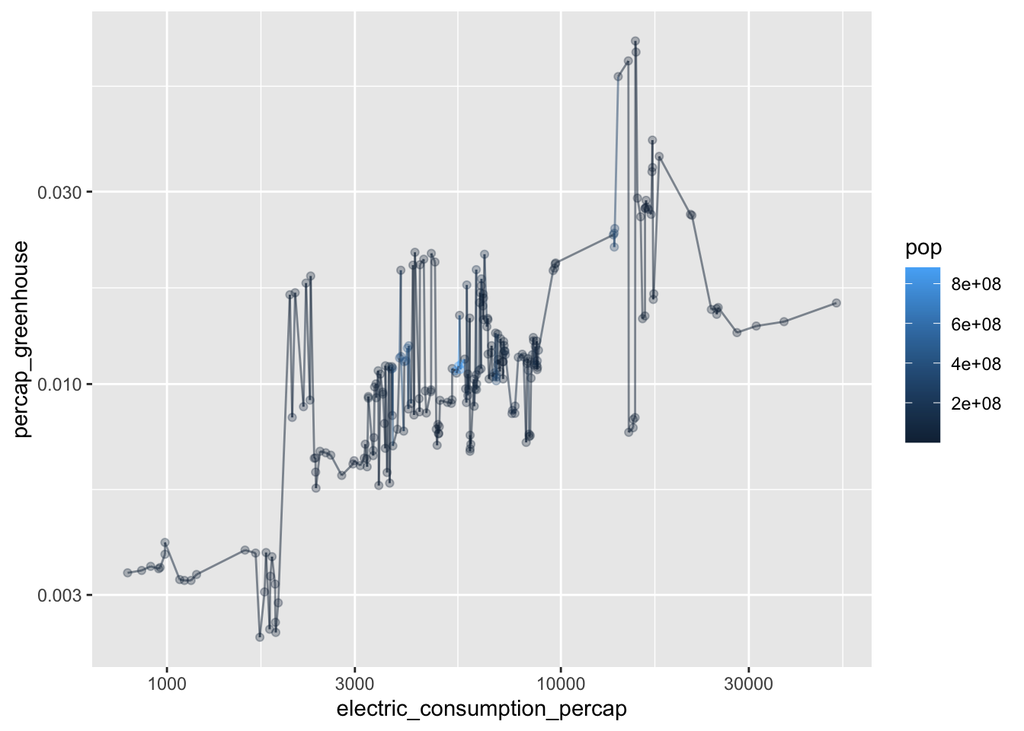

```r
ggplot(data = hydro_data_choice, aes(x = electric_consumption_percap, y = percap_greenhouse, color = pop)) +
  geom_point(alpha = .3) +
  geom_line(alpha = .5) +
  scale_y_log10() +
  scale_x_log10()
```

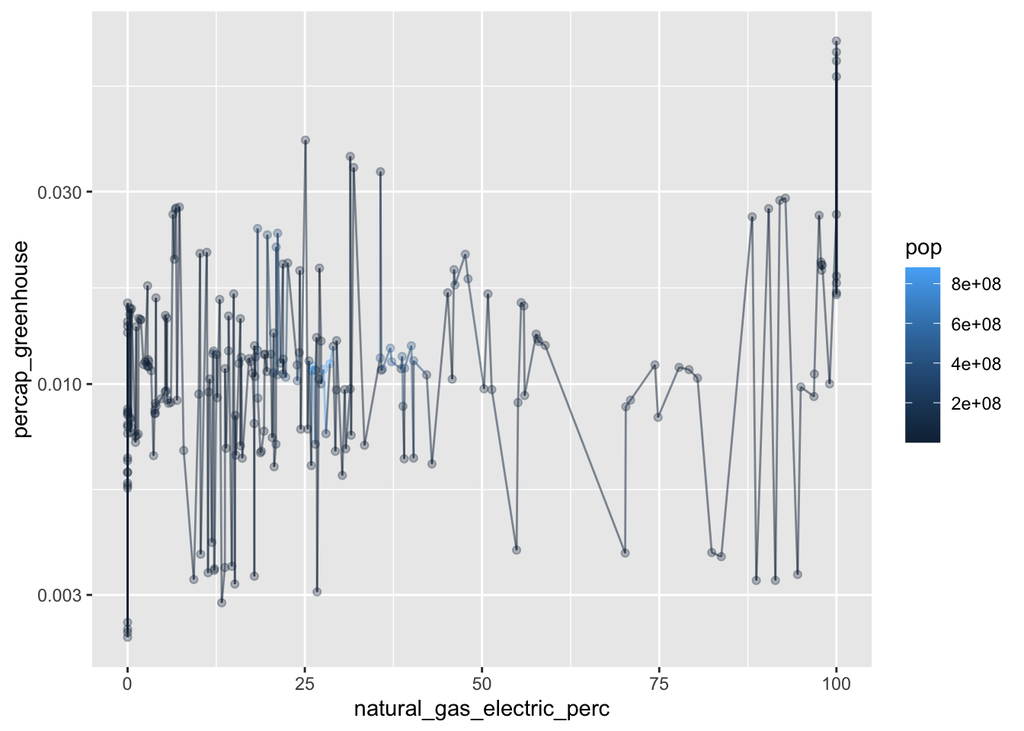

```r
ggplot(data = hydro_data_choice, aes(x = natural_gas_electric_perc, y = percap_greenhouse, color = pop)) +
  geom_point(alpha = .3) +
  geom_line(alpha = .5) +
  scale_y_log10()
```

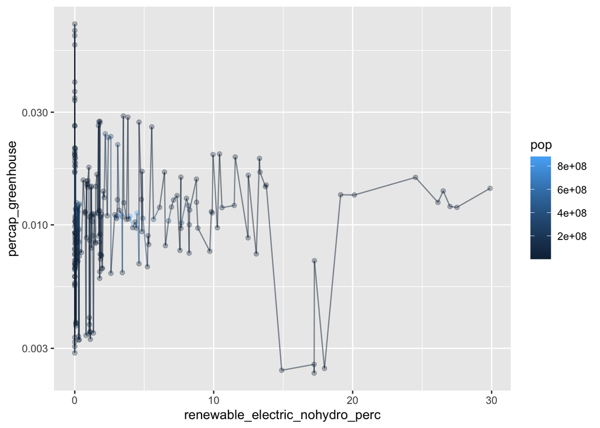

```r
ggplot(data = hydro_data_choice, aes(x = renewable_electric_nohydro_perc, y = percap_greenhouse, color = pop)) +
  geom_point(alpha = .3) +
  geom_line(alpha = .5) +
  scale_y_log10()
```

### One final interesting note is the percentage of people who have access to electricity has a negative estimate and is significant at the 5% level. This might suggest a flawed model, or something else. To get a better idea, a graph is shown below.

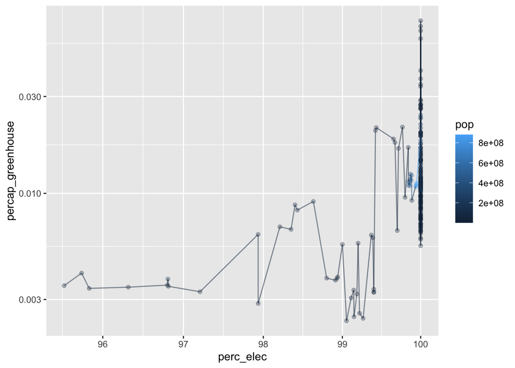

```r
ggplot(data = hydro_data_choice, aes(x = perc_elec, y = percap_greenhouse, color = pop)) +
  geom_point(alpha = .3) +
  geom_line(alpha = .5) +
  scale_y_log10() +
  scale_x_log10()
```

### The graph sheds some light onto this relationship. In a linear model, endogeneity (or error term correlating with X term) violates OLS assumptions and leads us to believe that this model is not well fit for testing the relationship between these two variables.

```r
hydro_norway_us <- hydro_data_subset %>%
filter(country_name == "Norway")
hydro_norway_us
```

```
## # A tibble: 4 x 23
##    time time_code country_name country_code co2_percap perc_elec gni_percap
##   <dbl> <chr>     <chr>        <chr>        <chr>      <chr>     <chr>
## 1  2005 YR2005    Norway       NOR          9.1792169… 100       63790
## 2  2006 YR2006    Norway       NOR          9.4958356… 100       69990
## 3  2007 YR2007    Norway       NOR          9.5748496… 100       78500
## 4  2008 YR2008    Norway       NOR          11.679583… 100       87520
## # … with 16 more variables: co2_emission <chr>, perc_co2_gaseous <chr>,
## #   perc_co2_solid_fuel <chr>, perc_co2_liquid_fuel <chr>,
## #   co2_methane_equiv.energy_sector <chr>, co2_methane_equiv.agriculture <chr>,
## #   co2_total_greenhouse_equiv <chr>, perc_safe_water <chr>,
## #   hydro_electric_perc <chr>, coal_electric_perc <chr>,
## #   natural_gas_electric_perc <chr>, nuclear_electric_perc <chr>,
## #   oil_gas_coal_electric_perc <chr>, renewable_electric_nohydro_perc <chr>,
## #   electric_consumption_percap <chr>, pop <chr>
```

```r
hydro_norway_s <- hydro_data_subset %>%
filter(country_name == "Germany")
hydro_norway_s
```

```
## # A tibble: 4 x 23
##    time time_code country_name country_code co2_percap perc_elec gni_percap
##   <dbl> <chr>     <chr>        <chr>        <chr>      <chr>     <chr>
## 1  2005 YR2005    Germany      DEU          9.6663722… 100       35710
## 2  2006 YR2006    Germany      DEU          9.9114760… 100       38230
## 3  2007 YR2007    Germany      DEU          9.4880398… 100       40440
## 4  2008 YR2008    Germany      DEU          9.5063211… 100       43570
## # … with 16 more variables: co2_emission <chr>, perc_co2_gaseous <chr>,
## #   perc_co2_solid_fuel <chr>, perc_co2_liquid_fuel <chr>,
## #   co2_methane_equiv.energy_sector <chr>, co2_methane_equiv.agriculture <chr>,
## #   co2_total_greenhouse_equiv <chr>, perc_safe_water <chr>,
## #   hydro_electric_perc <chr>, coal_electric_perc <chr>,
## #   natural_gas_electric_perc <chr>, nuclear_electric_perc <chr>,
## #   oil_gas_coal_electric_perc <chr>, renewable_electric_nohydro_perc <chr>,
## #   electric_consumption_percap <chr>, pop <chr>
```

```r
hydro_norway_s <- hydro_data_subset %>%
filter(country_name == "United States")
hydro_norway_s
```

```
## # A tibble: 4 x 23
##    time time_code country_name country_code co2_percap perc_elec gni_percap
##   <dbl> <chr>     <chr>        <chr>        <chr>      <chr>     <chr>
## 1  2005 YR2005    United Stat… USA          19.591885… 100       46190
## 2  2006 YR2006    United Stat… USA          19.094066… 100       47880
## 3  2007 YR2007    United Stat… USA          19.217897… 100       48500
## 4  2008 YR2008    United Stat… USA          18.461763… 100       48980
## # … with 16 more variables: co2_emission <chr>, perc_co2_gaseous <chr>,
## #   perc_co2_solid_fuel <chr>, perc_co2_liquid_fuel <chr>,
## #   co2_methane_equiv.energy_sector <chr>, co2_methane_equiv.agriculture <chr>,
## #   co2_total_greenhouse_equiv <chr>, perc_safe_water <chr>,
## #   hydro_electric_perc <chr>, coal_electric_perc <chr>,
## #   natural_gas_electric_perc <chr>, nuclear_electric_perc <chr>,
## #   oil_gas_coal_electric_perc <chr>, renewable_electric_nohydro_perc <chr>,
## #   electric_consumption_percap <chr>, pop <chr>
```